# Análisis estadístico: Detección de casos de anemia en menores de 5 años — Región San Martín

Víctor R

2025-09-22

```r
library(readxl)
library(dplyr)
library(janitor)
library(stringr)
library(rstatix)
library(ggplot2)
```

```r
# Carga de datos
path <- "C:\\Users\\USER\\Development\\UNA\\STATS-R\\datos\\ANEMIA_DA.xlsx"
df <- read_excel(path)
cat(">> Nombres originales:\n")
```

```
## >> Nombres originales:
```

```r
print(names(df))
```

```
##  [1] "PK_REGISTRO"             "FECHA_REGISTRO"
##  [3] "GENERO"                  "EDAD_REGISTRO"
##  [5] "TIPO_EDAD"               "ETNIA"
##  [7] "F_ATENCION"              "GRADO_SEVERIDAD"
##  [9] "DIAGNOSTICO"             "TIPO_DIAGNOSTICO"
## [11] "DESCRIPCION_FINANCIADOR" "CANTIDAD"
## [13] "PROVINCIA"               "DEPARTAMENTO"
## [15] "DISTRITO"                "RED"
## [17] "MICRORED"                "NOMBRE_ESTABLECIMIENTO"
## [19] "CODIGO_UNICO"            "LONGITUD"
## [21] "LATITUD"                 "FECHA_CORTE"
```

```r
df %>% glimpse()
```

```
## Rows: 59,225
## Columns: 22
## $ PK_REGISTRO             <dbl> 1, 2, 3, 4, 5, 6, 7, 8, 9, 10, 11, 12, 13, 14,…
## $ FECHA_REGISTRO          <dbl> 20180810, 20170406, 20180719, 20170912, 201807…
## $ GENERO                  <chr> "M", "M", "F", "M", "F", "F", "F", "F", "M", "…
## $ EDAD_REGISTRO           <dbl> 5, 3, 5, 4, 5, 5, 5, 4, 5, 4, 4, 5, 3, 4, 5, 4…
## $ TIPO_EDAD               <chr> "A", "A", "A", "A", "A", "A", "A", "A", "A", "…
## $ ETNIA                   <chr> "Mestizo", "Mestizo", "Mestizo", "Mestizo", "M…
## $ F_ATENCION              <dbl> 20180810, 20170406, 20180719, 20170912, 201807…
## $ GRADO_SEVERIDAD         <chr> "MOD", "LEV", "LEV", "LEV", "LEV", "LEV", "LEV…
## $ DIAGNOSTICO             <chr> "ANEMIA POR DEFICIENCIA DE HIERRO SIN ESPECIFI…
## $ TIPO_DIAGNOSTICO        <chr> "D", "D", "D", "D", "D", "D", "D", "D", "D", "…
## $ DESCRIPCION_FINANCIADOR <chr> "S.I.S", "S.I.S", "S.I.S", "S.I.S", "S.I.S", "…
## $ CANTIDAD                <dbl> 1, 1, 1, 1, 1, 1, 1, 1, 1, 1, 1, 1, 1, 1, 1, 1…
## $ PROVINCIA               <chr> "MARISCAL CACERES", "SAN MARTIN", "EL DORADO",…
## $ DEPARTAMENTO            <chr> "SAN MARTIN", "SAN MARTIN", "SAN MARTIN", "SAN…
## $ DISTRITO                <chr> "HUICUNGO", "TARAPOTO", "SAN JOSE DE SISA", "R…
## $ RED                     <chr> "MARISCAL CACERES", "SAN MARTIN", "EL DORADO",…
## $ MICRORED                <chr> "HUICUNGO", "TARAPOTO", "SAN JOSE DE SISA", "N…
## $ NOMBRE_ESTABLECIMIENTO  <chr> "PIZARRO", "HUAYCO TARAPOTO", "HOSPITAL RURAL …
## $ CODIGO_UNICO            <dbl> 6571, 6371, 6485, 6708, 6485, 6551, 6312, 6313…
## $ LONGITUD                <dbl> -76.98517, -76.36750, -76.68860, -77.23647, -7…
## $ LATITUD                 <dbl> -7.250180, -6.502062, -6.614755, -6.092303, -6…
## $ FECHA_CORTE             <dbl> 20250424, 20250424, 20250424, 20250424, 202504…
```

```r
nrow(df)
```

```
## [1] 59225
```

```r
# Limpieza básica y correccion

df <- df %>% clean_names
# corregir lev a LEV en grado_severidad
df <- df %>% mutate(grado_severidad = str_to_upper(grado_severidad))

# Parseo y normalización conservadora de EDAD_REGISTRO + TIPO_EDAD
df_clean <- df %>%
  mutate(
    # Guardar columnas originales por seguridad
    edad_raw = as.character(edad_registro),
    tipo_raw = as.character(tipo_edad),

    # Normalizar la unidad
    tipo_u = if_else(is.na(tipo_raw), NA_character_, toupper(str_trim(tipo_raw))),

    # Extraer solo números (sin permitir negativos)
    edad_num = as.numeric(str_extract(edad_raw, "\\d+\\.?\\d*")),

    # Inferir unidad: primero desde tipo_raw, luego desde el texto libre
    tipo_infer = case_when(
      tipo_u %in% c("A","AÑOS","AÑO","AN") ~ "A",
      tipo_u %in% c("M","MESES","MES")     ~ "M",
      tipo_u %in% c("D","DIAS","DÍA","DÍAS","DIA") ~ "D",
      str_detect(edad_raw, regex("años|año|anos", ignore_case = TRUE)) ~ "A",
      str_detect(edad_raw, regex("\\bmes\\b|meses", ignore_case = TRUE)) ~ "M",
      str_detect(edad_raw, regex("\\bd[ií]a|dias|días", ignore_case = TRUE)) ~ "D",
      TRUE ~ NA_character_
    ),

    # Conversión a meses
    edad_meses = case_when(
      !is.na(edad_num) & tipo_infer == "A" ~ edad_num * 12,
      !is.na(edad_num) & tipo_infer == "M" ~ edad_num,
      !is.na(edad_num) & tipo_infer == "D" ~ round(edad_num / 30, 1),
      TRUE ~ NA_real_
    ),

    # Flags de control de calidad
    edad_flag = case_when(
      is.na(edad_num) & is.na(tipo_infer)   ~ "no_parse_no_unit",
      is.na(edad_meses)                     ~ "parse_failed_or_no_unit",
      edad_num < 0                          ~ "negative_input",
      edad_meses >= 60                      ~ "out_of_range_>=60_months",
      TRUE                                  ~ "ok"
    )
  )

# Resumen de las banderas de calidad
df_clean %>%
  count(edad_flag) %>%
  arrange(desc(n)) %>%
  print(n = 20)
```

```
## # A tibble: 2 × 2
##   edad_flag                    n
##   <chr>                    <int>
## 1 ok                       57212
## 2 out_of_range_>=60_months  2013
```

```r
# Dataset final solo con casos válidos (< 60 meses y no NA)
df_for_analysis <- df_clean %>%
  filter(!is.na(edad_meses) & edad_meses >= 0 & edad_meses < 60)

nrow(df_for_analysis)
```

```
## [1] 57212
```

```r
# EXPORTAR A CSV para análisis en SPSS o similar
write.csv(df_for_analysis, "datos/ANEMIA_DA_clean.csv", row.names = FALSE)
```

```r
# NO SE USO PORQUE LAS PROPORCIONES DE GENERO NO ESTAN TAN DISPARADAS

set.seed(123)

# Número mínimo de casos entre los géneros
n_min <- df_for_analysis %>% count(genero) %>% summarise(minimo = min(n)) %>% pull(minimo)

# Muestra balanceada
muestra_balanceada <- df_for_analysis %>%
  group_by(genero) %>%
  sample_n(n_min) %>%
  ungroup()

table(muestra_balanceada$genero)
```

```
##
##     F     M
## 27092 27092
```

```r
nrow(muestra_balanceada)
```

```
## [1] 54184
```

```r
# Frecuencias de género
tab_genero <- df_for_analysis %>% tabyl(genero)
tab_genero
```

| genero | n | percent |
| --- | --- | --- |
| F | 27092 | 0.473537 |
| M | 30120 | 0.526463 |

```r
# Severidad de anemia
tab_severidad <- df_for_analysis %>% tabyl(grado_severidad)
tab_severidad
```

| grado_severidad | n | percent |
| --- | --- | --- |
| LEV | 44732 | 0.781863945 |
| MOD | 12237 | 0.213888695 |
| SEV | 243 | 0.004247361 |

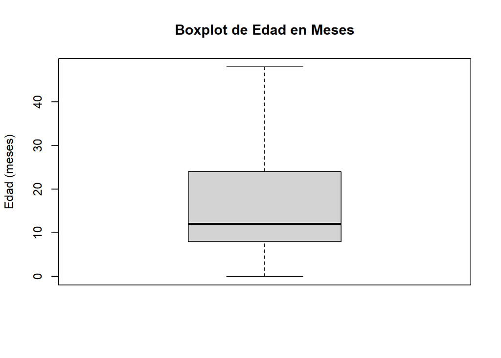

```r
# Edad datos atipicos
boxplot(df_for_analysis$edad_meses, main = "Boxplot de Edad en Meses", ylab = "Edad (meses)")
```

```r
summary(df_for_analysis)
```

```
##   pk_registro    fecha_registro        genero          edad_registro
##  Min.   :    2   Min.   :20160101   Length:57212       Min.   :-2.000
##  1st Qu.:15517   1st Qu.:20181211   Class :character   1st Qu.: 1.000
##  Median :29961   Median :20200908   Mode  :character   Median : 2.000
##  Mean   :30039   Mean   :20203905                      Mean   : 3.426
##  3rd Qu.:44907   3rd Qu.:20220921                      3rd Qu.: 6.000
##  Max.   :59225   Max.   :20250426                      Max.   :27.000
##   tipo_edad            etnia             f_atencion       grado_severidad
##  Length:57212       Length:57212       Min.   :20160101   Length:57212
##  Class :character   Class :character   1st Qu.:20181211   Class :character
##  Mode  :character   Mode  :character   Median :20200908   Mode  :character
##                                        Mean   :20203905
##                                        3rd Qu.:20220921
##                                        Max.   :20250426
##  diagnostico        tipo_diagnostico   descripcion_financiador    cantidad
##  Length:57212       Length:57212       Length:57212            Min.   :1.000
##  Class :character   Class :character   Class :character        1st Qu.:1.000
##  Mode  :character   Mode  :character   Mode  :character        Median :1.000
##                                                                Mean   :1.007
##                                                                3rd Qu.:1.000
##                                                                Max.   :3.000
##   provincia         departamento         distrito             red
##  Length:57212       Length:57212       Length:57212       Length:57212
##  Class :character   Class :character   Class :character   Class :character
##  Mode  :character   Mode  :character   Mode  :character   Mode  :character
##
##
##
##    microred         nombre_establecimiento  codigo_unico      longitud
##  Length:57212       Length:57212           Min.   : 6270   Min.   :-77.63
##  Class :character   Class :character       1st Qu.: 6351   1st Qu.:-76.85
##  Mode  :character   Mode  :character       Median : 6396   Median :-76.58
##                                            Mean   : 6503   Mean   :-76.62
##                                            3rd Qu.: 6493   3rd Qu.:-76.36
##                                            Max.   :31276   Max.   :-75.59
##     latitud        fecha_corte         edad_raw           tipo_raw
##  Min.   :-8.754   Min.   :20250424   Length:57212       Length:57212
##  1st Qu.:-6.779   1st Qu.:20250424   Class :character   Class :character
##  Median :-6.486   Median :20250424   Mode  :character   Mode  :character
##  Mean   :-6.602   Mean   :20250424
##  3rd Qu.:-6.154   3rd Qu.:20250424
##  Max.   :-5.639   Max.   :20250424
##     tipo_u             edad_num       tipo_infer          edad_meses
##  Length:57212       Min.   : 1.000   Length:57212       Min.   : 0.00
##  Class :character   1st Qu.: 1.000   Class :character   1st Qu.: 8.00
##  Mode  :character   Median : 2.000   Mode  :character   Median :12.00
##                     Mean   : 3.426                      Mean   :17.25
##                     3rd Qu.: 6.000                      3rd Qu.:24.00
##                     Max.   :27.000                      Max.   :48.00
##   edad_flag
##  Length:57212
##  Class :character
##  Mode  :character
##
##
##
```

# HIPOTESIS CON UN Nivel de significancia elegido: α = 0.05.

# Hipótesis 1: ¿Existe asociación entre género y grado de severidad de la anemia?

## H0 (nula): No existe relación entre género y severidad.

## H1 (alternativa): Sí existe relación entre género y severidad.

```r
tabla_bi <- table(df_for_analysis$genero, df_for_analysis$grado_severidad)
chisq.test(tabla_bi)
```

```
##
##  Pearson's Chi-squared test
##
## data:  tabla_bi
## X-squared = 42.039, df = 2, p-value = 7.437e-10
```

Decisión: Como p < 0.05, se rechaza H0.

Interpretación: Existe evidencia estadísticamente significativa de que el género y el grado de severidad de la anemia no son independientes. Esto significa que la severidad (leve, moderada, severa) se distribuye de forma diferente entre niños y niñas.

Nota: El test chi-cuadrado indica asociación, pero no muestra la magnitud ni dirección de esa asociación.

# Hipótesis 2: ¿La edad se asocia con el grado de severidad?

## H0: La edad promedio es igual entre los grupos de severidad.

## H1: Al menos un grupo difiere.

```r
df_for_analysis %>%
  anova_test(edad_meses ~ grado_severidad)
```

|  | Effect | DFn | DFd | F | p | p<.05 | ges |
| --- | --- | --- | --- | --- | --- | --- | --- |
| 1 | grado_severidad | 2 | 57209 | 319.31 | 1.24e-138 | * | 0.011 |

Resultados del ANOVA: F(2, 57,209) = 319.31, p < 0.001, ges = 0.011

Decisión: Se rechaza H0.

Interpretación: Existen diferencias estadísticamente significativas en la edad promedio entre los grupos de severidad. Sin embargo, el tamaño del efecto es muy pequeño (ges = 0.011). Esto indica que la edad tiene una influencia muy débil sobre la severidad de la anemia, sin relevancia clínica considerable.

# Hipótesis 3: ¿Existe correlación entre edad y cantidad de diagnósticos?

## H0: No hay correlación.

## H1: Sí hay correlación.

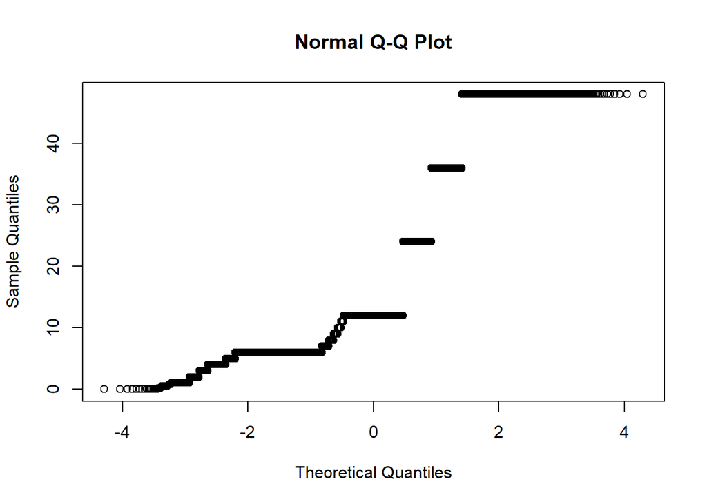

```r
# Q-Q plot
qqnorm(df_for_analysis$edad_meses)
```

```r
# No es normalidad, pero con gran n, se puede usar Pearson

cor.test(df_for_analysis$edad_meses, df_for_analysis$cantidad, method = "pearson")
```

```
##
##  Pearson's product-moment correlation
##
## data:  df_for_analysis$edad_meses and df_for_analysis$cantidad
## t = -0.91459, df = 57210, p-value = 0.3604
## alternative hypothesis: true correlation is not equal to 0
## 95 percent confidence interval:
##  -0.01201754  0.00437061
## sample estimates:
##         cor
## -0.00382372
```

Resultados del test de correlación de Pearson: r = -0.0038, IC95% [-0.0120, 0.0044], t = -0.91, gl = 57,210, p = 0.360

Decisión: No se rechaza H0.

Interpretación: No existe correlación estadísticamente significativa entre la edad y la cantidad de diagnósticos. El coeficiente de correlación es cercano a 0, lo que indica ausencia de relación lineal entre ambas variables.

*OJO: El valor p no te dice si la relación es importante, solo si es estadísticamente detectable. La interpretación debe incluir el contexto y el tamaño del efecto.*

```r
# Provincia vs Severidad
table(df_for_analysis$provincia, df_for_analysis$grado_severidad)
```

```
##
##                      LEV   MOD   SEV
##   BELLAVISTA        2896   429    15
##   EL DORADO         3222   844    32
##   HUALLAGA           563    99     0
##   LAMAS             6444  1535    26
##   MARISCAL CACERES  3048   588     6
##   MOYOBAMBA         4899  1320    16
##   PICOTA            1812   472    14
##   RIOJA             6031  1462    28
##   SAN MARTIN       12659  4328    82
##   TOCACHE           3158  1160    24
```

```r
# Edad vs Severidad
table(df_for_analysis$edad_meses, df_for_analysis$grado_severidad)
```

```
##
##         LEV   MOD   SEV
##   0      14     2     0
##   0.1     1     0     0
##   0.2     3     0     0
##   0.4     1     0     0
##   0.5     6     2     0
##   0.6     1     0     0
##   0.7     2     0     0
##   0.8     3     0     0
##   0.9     1     0     0
##   1      55     2     2
##   2      49    11     1
##   3      61    14     4
##   4     257    38     3
##   5     186    68     0
##   6    8141  2733    48
##   7    1459   510    11
##   8     998   283     7
##   9    1014   297     2
##   10    787   216     6
##   11    666   168     4
##   12  15641  5148    98
##   24   6635  1389    26
##   36   4774   792    19
##   48   3977   564    12
```

```r
# Genero vs Severidad
table(df_for_analysis$genero, df_for_analysis$grado_severidad)
```

```
##
##       LEV   MOD   SEV
##   F 21498  5493   101
##   M 23234  6744   142
```

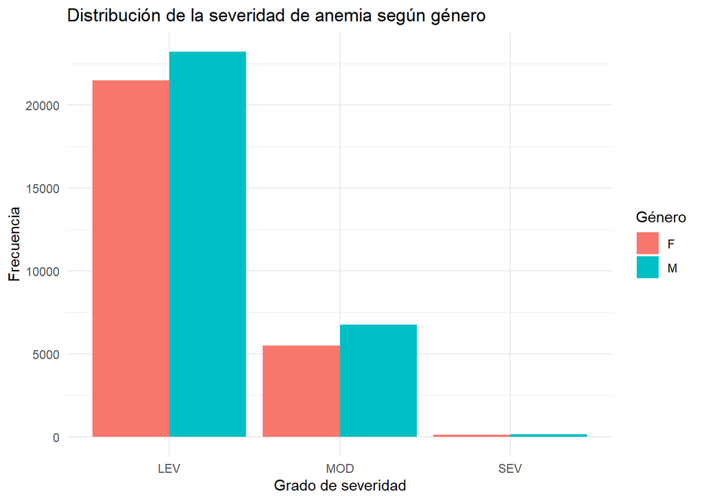

```r
# Tabla de proporciones

ggplot(df_for_analysis, aes(x = grado_severidad, fill = genero)) +
  geom_bar(position = "dodge") +
  labs(
    title = "Distribución de la severidad de anemia según género",
    x = "Grado de severidad",
    y = "Frecuencia",
    fill = "Género"
  ) +
  theme_minimal()
```

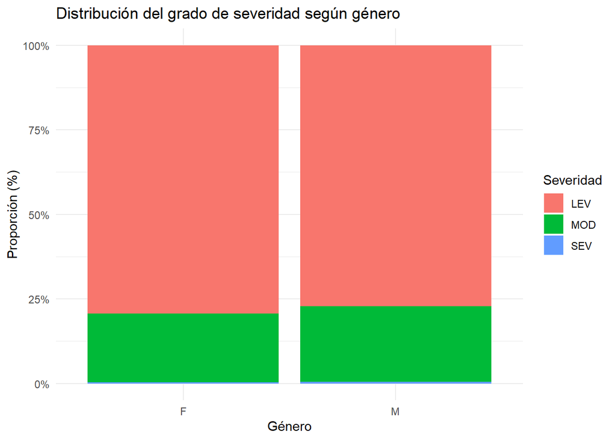

```r
prop_tab <- df_for_analysis %>%
  count(genero, grado_severidad) %>%
  group_by(genero) %>%
  mutate(prop = n / sum(n))

# Barras porcentuales
ggplot(prop_tab, aes(x = genero, y = prop, fill = grado_severidad)) +
  geom_bar(stat = "identity", position = "fill") +
  scale_y_continuous(labels = scales::percent) +
  labs(
    title = "Distribución del grado de severidad según género",
    x = "Género",
    y = "Proporción (%)",
    fill = "Severidad"
  ) +
  theme_minimal()
```

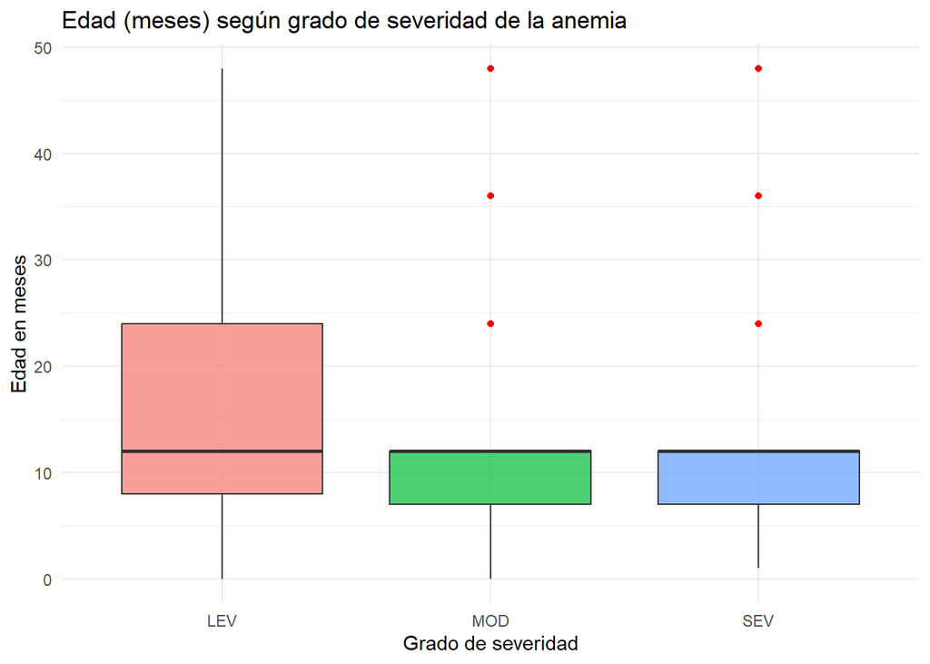

```r
ggplot(df_for_analysis, aes(x = grado_severidad, y = edad_meses, fill = grado_severidad)) +
  geom_boxplot(alpha = 0.7, outlier.color = "red") +
  labs(
    title = "Edad (meses) según grado de severidad de la anemia",
    x = "Grado de severidad",
    y = "Edad en meses"
  ) +
  theme_minimal() +
  theme(legend.position = "none")
```

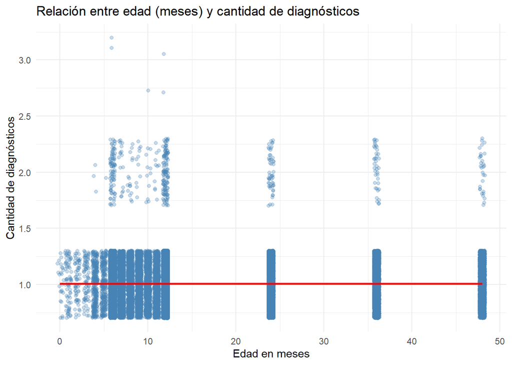

```r
ggplot(df_for_analysis, aes(x = edad_meses, y = cantidad)) +
  geom_jitter(alpha = 0.3, width = 0.3, height = 0.3, color = "steelblue") +
  geom_smooth(method = "lm", se = TRUE, color = "red") + # Línea de regresión
  labs(
    title = "Relación entre edad (meses) y cantidad de diagnósticos",
    x = "Edad en meses",
    y = "Cantidad de diagnósticos"
  ) +
  theme_minimal()
```